# Born at Risk: Newborn Mortality

Author

Boluwatife Adesoye

## Introduction

Neonatal mortality remains a major global health challenge because deaths in the first 28 days of life account for a large share of under-five mortality. This report uses UNICEF data to examine how that burden has changed over time, which countries are most affected, and how the pattern differs across the world.

The goal is to show not just how large the problem is, but also where it is most concentrated and how it has evolved.

## Data and methods

This report uses UNICEF indicator data on **neonatal deaths as a percentage of under-five deaths**. The dataset includes country names, country codes, and yearly values, which makes it possible to compare countries and track change over time.

To make the analysis clearer, I filtered the data to keep only the neonatal mortality indicator and created three views of the same dataset: a global yearly average, the top countries in the latest year, and a country-level map for the latest year. I also used the country codes to join the UNICEF data to a world boundary file for the map.

The report focuses on one main question: where is newborn mortality most concentrated, and how has its share of child deaths changed over time?

```python
import polars as pl
from plotnine import *
```

```python
# Load UNICEF indicator 1 and metadata
ind1 = pl.read_csv("unicef_indicator_1.csv")
meta = pl.read_csv("unicef_metadata.csv")

ind1.head()
```

shape: (5, 14)

| country str | alpha_2_code str | alpha_3_code str | numeric_code i64 | indicator str | time_period i64 | obs_value f64 | sex str | unit_multiplier str | unit_of_measure str | observation_status str | observation_confidentaility str | time_period_activity_related_to_when_the_data_are_collected str | current_age str |
| --- | --- | --- | --- | --- | --- | --- | --- | --- | --- | --- | --- | --- | --- |
| "Afghanistan" | "AF" | "AFG" | 4 | "Neonatal deaths as a percentag… | 1990 | 0.439955 | "Total" | null | "%" | "Normal value" | null | null | "Total" |
| "Afghanistan" | "AF" | "AFG" | 4 | "Neonatal deaths as a percentag… | 1991 | 0.43921 | "Total" | null | "%" | "Normal value" | null | null | "Total" |
| "Afghanistan" | "AF" | "AFG" | 4 | "Neonatal deaths as a percentag… | 1992 | 0.452914 | "Total" | null | "%" | "Normal value" | null | null | "Total" |
| "Afghanistan" | "AF" | "AFG" | 4 | "Neonatal deaths as a percentag… | 1993 | 0.480913 | "Total" | null | "%" | "Normal value" | null | null | "Total" |
| "Afghanistan" | "AF" | "AFG" | 4 | "Neonatal deaths as a percentag… | 1994 | 0.489584 | "Total" | null | "%" | "Normal value" | null | null | "Total" |

```python
# Keep only the neonatal indicator and useful columns
df = (
    ind1
    .filter(pl.col("indicator") == "Neonatal deaths as a percentage of under-five deaths")
    .with_columns(
        (pl.col("obs_value") * 100).alias("neonatal_share_pct"),
        pl.col("time_period").cast(pl.Int32)
    )
    .select("country", "alpha_3_code", "time_period", "neonatal_share_pct")
)

# Latest year for country comparison
latest_year = df["time_period"].max()
df_latest = df.filter(pl.col("time_period") == latest_year)

# Global average per year for time-series
df_global = (
    df
    .group_by("time_period")
    .agg(pl.mean("neonatal_share_pct").alias("global_avg_pct"))
)

latest_year, df.shape, df_latest.shape, df_global.shape
```

```
(2023, (6742, 4), (197, 4), (34, 2))
```

# Results

## Global trend

This chart shows that the global share of under-five deaths occurring in the newborn period has generally risen over time. The increase is gradual, but the overall direction is clear. That means neonatal mortality remains an important part of the child survival picture even as broader mortality patterns change.

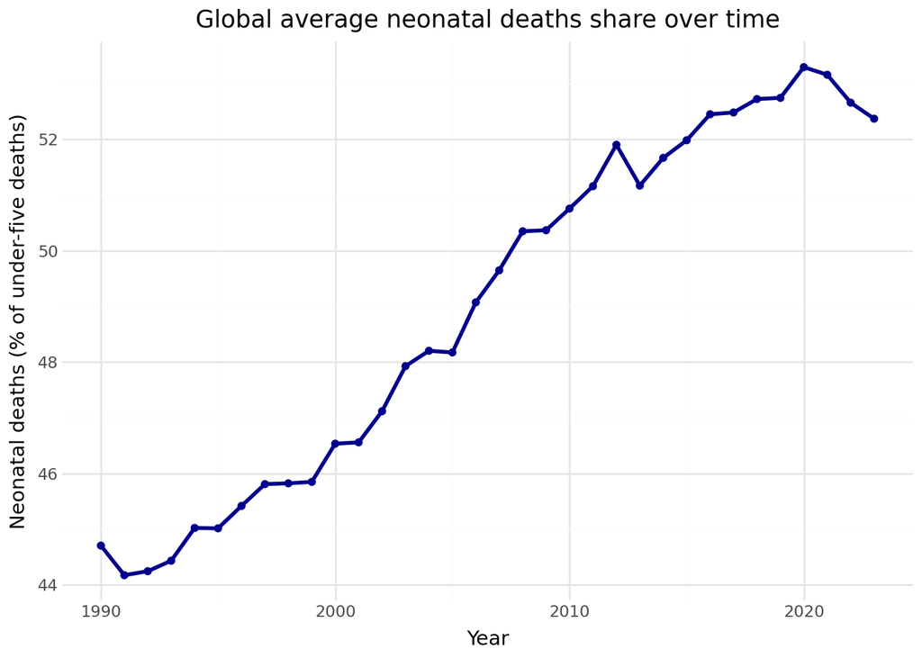

```python
import pandas as pd
df_global_pd = df_global.to_pandas()

(
    ggplot(df_global_pd)
    + aes(x="time_period", y="global_avg_pct")
    + geom_line(color="darkblue", size=1.2)
    + geom_point(color="darkblue", size=1.5)
    + labs(
        title="Global average neonatal deaths share over time",
        x="Year",
        y="Neonatal deaths (% of under-five deaths)"
    )
    + theme_minimal()
)
```

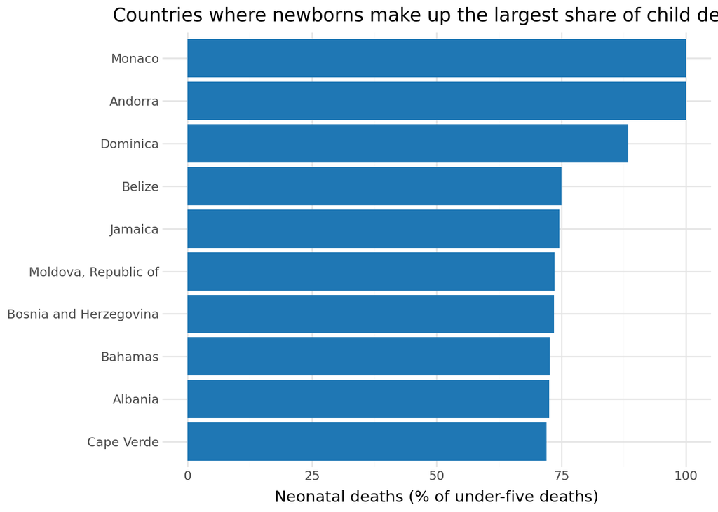

```python
df_latest_pd = (
    df_latest
    .sort("neonatal_share_pct", descending=True)
    .head(10)
    .to_pandas()
)

(
    ggplot(df_latest_pd)
    + aes(x="reorder(country, neonatal_share_pct)", y="neonatal_share_pct")
    + geom_col(fill="#1f77b4")
    + coord_flip()
    + labs(
        title="Countries where newborns make up the largest share of child deaths",
        x="",
        y="Neonatal deaths (% of under-five deaths)"
    )
    + theme_minimal()
)
```

The bar chart highlights the countries where neonatal deaths make up the largest share of under-five deaths. Countries such as Monaco and Andorra appear at the top, showing that the proportion can be especially high in some places. This chart makes cross-country differences much easier to compare.

## Relationship between year and neonatal death share

This scatterplot shows a weak but visible upward relationship between year and neonatal death share. The fitted line suggests that the share of under-five deaths occurring in the neonatal period has tended to increase over time. Although the observations vary widely, the overall trend still points upward.

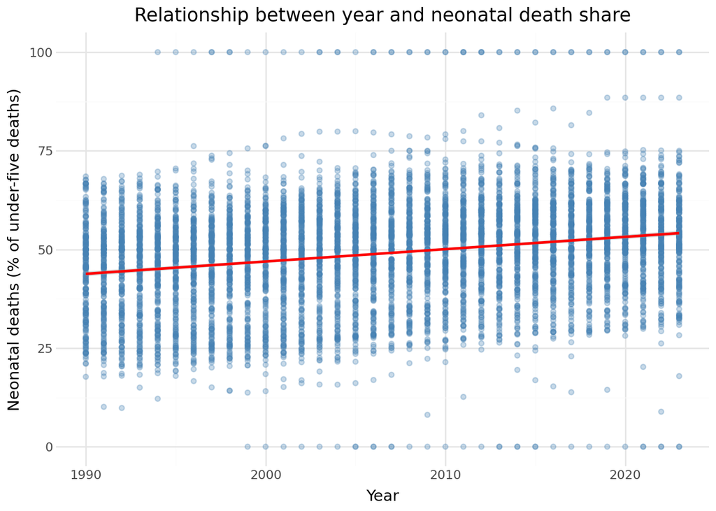

```python
df_pd = df.to_pandas()

(
    ggplot(df_pd)
    + aes(x="time_period", y="neonatal_share_pct")
    + geom_point(alpha=0.3, color="steelblue")
    + geom_smooth(method="lm", se=True, color="red")
    + labs(
        title="Relationship between year and neonatal death share",
        x="Year",
        y="Neonatal deaths (% of under-five deaths)"
    )
    + theme_minimal()
)
```

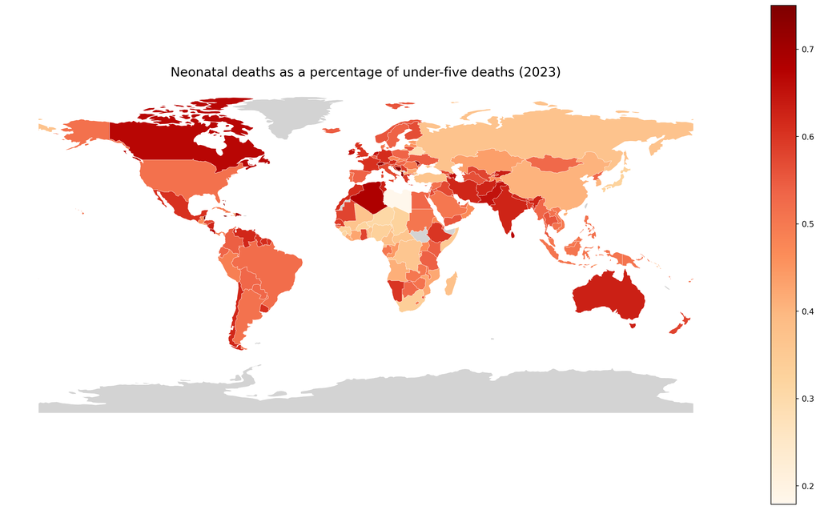

[figure not shown]

```python
import pandas as pd
import geopandas as gpd
import matplotlib.pyplot as plt

# Load the UNICEF data
df = pd.read_csv("unicef_indicator_1.csv")

# Keep only the indicator you are analysing
df = df[df["indicator"] == "Neonatal deaths as a percentage of under-five deaths"].copy()

# Get the latest year in the dataset
latest_year = df["time_period"].max()

# Keep only data for the latest year
df_latest = df[df["time_period"] == latest_year].copy()

# Keep only the columns needed for the map
df_latest = df_latest[["alpha_3_code", "country", "obs_value"]].dropna()

# Load the world boundaries file from Natural Earth
world_url = "https://naturalearth.s3.amazonaws.com/110m_cultural/ne_110m_admin_0_countries.zip"
world = gpd.read_file(world_url)

# Match the country code column to your UNICEF data
world = world.rename(columns={"ADM0_A3": "alpha_3_code"})

# Join the UNICEF values onto the world map
world_map = world.merge(df_latest, on="alpha_3_code", how="left")

# Create the plot
fig, ax = plt.subplots(figsize=(16, 9))

world_map.plot(
    column="obs_value",
    ax=ax,
    cmap="OrRd",
    legend=True,
    edgecolor="white",
    linewidth=0.3,
    missing_kwds={
        "color": "lightgrey",
        "label": "No data"
    }
)

ax.set_title(f"Neonatal deaths as a percentage of under-five deaths ({latest_year})", fontsize=16)
ax.set_axis_off()

plt.tight_layout()
fig
```

## Conclusion

Overall, the charts show that neonatal mortality remains a serious and uneven global issue. The burden is concentrated in particular countries and regions, and the time trend suggests that newborn deaths continue to make up a substantial share of child mortality. These patterns point to the need for targeted interventions that focus on the earliest stage of life.

[output not shown]